# Stack

Stack dalam Python adalah jenis koleksi yang digunakan untuk mengatur dan mengelola data dalam urutan tertentu.  
Elemen dalam stack ditambahkan dan dihapus hanya dari satu ujung, yang disebut bagian atas.

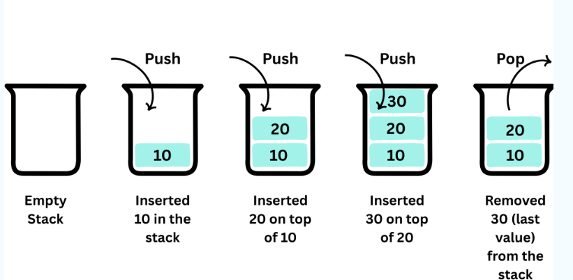

Seperti tumpukan pancake, pancake ditambahkan dan dikeluarkan dari atas. Jadi, ketika mengeluarkan pancake, itu selalu pancake terakhir yang Anda tambahkan. Cara mengatur elemen seperti ini disebut LIFO: Last In First Out (Terakhir Masuk, Pertama Keluar).

Operasi dasar yang dapat kita lakukan pada sebuah stack adalah:

- Push: Menambahkan elemen baru ke dalam tumpukan.
- Pop: Menghapus dan mengembalikan elemen teratas dari tumpukan.
- Peek: Mengembalikan elemen teratas (terakhir) pada tumpukan.
- isEmpty: Memeriksa apakah tumpukan kosong.
- Ukuran: Menemukan jumlah elemen dalam tumpukan.

Stack dapat diimplementasikan dengan menggunakan array atau linked list.

Stack dapat digunakan untuk mengimplementasikan mekanisme undo, untuk kembali ke keadaan sebelumnya, untuk membuat algoritma pencarian mendalam (depth-first search) dalam graf, atau untuk penelusuran balik (backtracking).

Stack sering disebut bersamaan dengan Queue, yang merupakan struktur data serupa yang dijelaskan pada halaman berikutnya.

#### Menggunakan daftar Python sebagai tumpukan

```python
stack = []

# Push
stack.append('A')
stack.append('B')
stack.append('C')
print("Stack: ", stack)

# Peek
topElement = stack[-1]
print("Peek: ", topElement)

# Pop
poppedElement = stack.pop()
print("Pop: ", poppedElement)

# Stack after Pop
print("Stack after Pop: ", stack)

# isEmpty
isEmpty = not bool(stack)
print("isEmpty: ", isEmpty)

# Size
print("Size: ",len(stack))
```

```
Stack:  ['A', 'B', 'C']
Peek:  C
Pop:  C
Stack after Pop:  ['A', 'B']
isEmpty:  False
Size:  2
```

#### Membuat tumpukan menggunakan kelas

```python
class Stack:
  def __init__(self):
    self.stack = []

  def push(self, element):
    self.stack.append(element)

  def pop(self):
    if self.isEmpty():
      return "Stack is empty"
    return self.stack.pop()

  def peek(self):
    if self.isEmpty():
      return "Stack is empty"
    return self.stack[-1]

  def isEmpty(self):
    return len(self.stack) == 0

  def size(self):
    return len(self.stack)

# Create a stack
myStack = Stack()

myStack.push('A')
myStack.push('B')
myStack.push('C')

print("Stack: ", myStack.stack)
print("Pop: ", myStack.pop())
print("Stack after Pop: ", myStack.stack)
print("Peek: ", myStack.peek())
print("isEmpty: ", myStack.isEmpty())
print("Size: ", myStack.size())
```

```
Stack:  ['A', 'B', 'C']
Pop:  C
Stack after Pop:  ['A', 'B']
Peek:  B
isEmpty:  False
Size:  2
```

#### Membuat Stack menggunakan Linked List

```python
class Node:
  def __init__(self, value):
    self.value = value
    self.next = None

class Stack:
  def __init__(self):
    self.head = None
    self.size = 0

  def push(self, value):
    new_node = Node(value)
    if self.head:
      new_node.next = self.head
    self.head = new_node
    self.size += 1

  def pop(self):
    if self.isEmpty():
      return "Stack is empty"
    popped_node = self.head
    self.head = self.head.next
    self.size -= 1
    return popped_node.value

  def peek(self):
    if self.isEmpty():
      return "Stack is empty"
    return self.head.value

  def isEmpty(self):
    return self.size == 0

  def stackSize(self):
    return self.size

  def traverseAndPrint(self):
    currentNode = self.head
    while currentNode:
      print(currentNode.value, end=" -> ")
      currentNode = currentNode.next
    print()

myStack = Stack()
myStack.push('A')
myStack.push('B')
myStack.push('C')

print("LinkedList: ", end="")
myStack.traverseAndPrint()
print("Peek: ", myStack.peek())
print("Pop: ", myStack.pop())
print("LinkedList after Pop: ", end="")
myStack.traverseAndPrint()
print("isEmpty: ", myStack.isEmpty())
print("Size: ", myStack.stackSize())
```

```
LinkedList: C -> B -> A ->
Peek:  C
Pop:  C
LinkedList after Pop: B -> A ->
isEmpty:  False
Size:  2
```

### Contoh Soal

```python
class StackNama:
    def __init__(self):
        self.items = []

    def push(self, data):
        self.items.append(data)
        print(f"Push: Huruf '{data}' ditambahkan.")

    def pop(self):
        if not self.is_empty():
            return self.items.pop()
        return "Stack kosong!"

    def peek(self):
        if not self.is_empty():
            return self.items[-1]
        return "Stack kosong!"

    def size(self):
        return len(self.items)

    def is_empty(self):
        return len(self.items) == 0

stack = StackNama()

for huruf in "PUTRA":
    stack.push(huruf)

print(f"Huruf paling atas (Peek): {stack.peek()}")
print(f"Jumlah huruf dalam stack (Size): {stack.size()}")
print(f"Melakukan Pop: {stack.pop()} dikeluarkan.")
print(f"Huruf teratas sekarang: {stack.peek()}")
print(f"Jumlah huruf sekarang: {stack.size()}")
```

```
Push: Huruf 'P' ditambahkan.
Push: Huruf 'U' ditambahkan.
Push: Huruf 'T' ditambahkan.
Push: Huruf 'R' ditambahkan.
Push: Huruf 'A' ditambahkan.
Huruf paling atas (Peek): A
Jumlah huruf dalam stack (Size): 5
Melakukan Pop: A dikeluarkan.
Huruf teratas sekarang: R
Jumlah huruf sekarang: 4
```

##### Latihan Soal

1.Apa yang dimaksud dengan struktur data Stack? A. Struktur data dengan prinsip FIFO  
B. Struktur data dengan prinsip LIFO  
C. Struktur data berbentuk pohon  
D. Struktur data berbentuk graf  
**Jawaban :** B. Struktur Data dengan Prinsip LIFO

2.Operasi utama pada Stack adalah… A. Insert dan Delete  
B. Push dan Pop  
C. Enqueue dan Dequeue  
D. Search dan Sort  
**Jawaban :** B. Push dan Pop

3.Jika stack berisi:  
[10, 20, 30]  
Elemen terakhir yang dimasukkan adalah?  
**Jawaban :** 30

4.Jika dilakukan operasi pop() pada stack:  
[5, 8, 12, 20]  
Maka elemen yang keluar adalah?  
**Jawaban :** 20

5.Diketahui stack kosong. Lakukan:  
Push(A)  
Push(B)  
Push(C)  
Pop()  
Pop()  
Push(D)  
Tentukan isi stack akhir!  
**Jawaban :** (A,D)

6.Diketahui stack kosong. Lakukan operasi berikut:  
Push(10)  
Push(15)  
Push(20)  
Pop()  
Push(25)  
Tentukan isi stack akhir!  
**Jawaban :** (10,15,25)

7.Buatlah fungsi untuk mengecek apakah suatu string merupakan palindrome menggunakan stack.  
Input: "KATAK"  
Output: Palindrome  
**Jawaban :**

```python
class Stack:
    data = []

    def push(self, huruf):
        self.data.append(huruf)

    def pop(self):
        return self.data.pop()

    def size(self):
        return len(self.data)

kata_asli = "KATAK"
s = Stack()

for h in kata_asli:
    s.push(h)

kata_terbalik = ""
while s.size() > 0:
    kata_terbalik += s.pop()

print("Kata Asli:", kata_asli)
print("Kata Terbalik:", kata_terbalik)

if kata_asli == kata_terbalik:
    print("KESIMPULAN: Palindrome")
else:
    print("KESIMPULAN: Bukan Palindrome")
```

```
Kata Asli: KATAK
Kata Terbalik: KATAK
KESIMPULAN: Palindrome
```

1. Riwayat Undo (Simulasi Undo Text Editor)  
   Buatlah program sederhana untuk mensimulasikan fitur Undo pada editor teks.  
   Ketentuan:  
   User memasukkan beberapa teks.  
   Setiap input disimpan ke dalam stack.  
   Jika user mengetik UNDO, maka teks terakhir dihapus.  
   Contoh:  
   Input: Halo  
   Input: Dunia  
   Input: Belajar Stack  
   Input: UNDO  
   Output: Dunia

```python
stack_undo = []

print("Simulasi Undo Text Editor (Ketik 'EXIT' untuk keluar)")

while True:
    teks = input("Input: ")

    if teks.upper() == "UNDO":
        if len(stack_undo) > 0:
            stack_undo.pop()
            if len(stack_undo) > 0:
                print("Output:", stack_undo[-1])
            else:
                print("Output: (Kosong)")
        else:
            print("Output: Tidak ada yang bisa di-undo")

    elif teks.upper() == "EXIT":
        break

    else:
        stack_undo.append(teks)
```

```
Simulasi Undo Text Editor (Ketik 'EXIT' untuk keluar)
```

```
Output: Tidak ada yang bisa di-undo
```

```
Output: HALO
```

2. Buat program untuk membalik urutan kata dalam sebuah kalimat menggunakan stack.  
   Input: Saya belajar struktur data  
   Output: data struktur belajar Saya

```python
kalimat = "Saya belajar struktur data"
daftar_kata = kalimat.split()

wadah_tumpukan = []

for kata in daftar_kata:
    wadah_tumpukan.append(kata)

hasil_akhir = []
while wadah_tumpukan:
    kata_diambil = wadah_tumpukan.pop()
    hasil_akhir.append(kata_diambil)

print("Hasilnya:", " ".join(hasil_akhir))
```

```
Hasilnya: data struktur belajar Saya
```

3. Buat program yang:  
   Mengisi stack dengan beberapa angka.  
   Menghitung jumlah elemen dalam stack tanpa menggunakan fungsi bawaan len()

```python
tumpukan_angka = [10, 20, 30, 40, 50]
kardus_sementara = []
hitung_jari = 0

while tumpukan_angka:
    angka = tumpukan_angka.pop()
    kardus_sementara.append(angka)
    hitung_jari = hitung_jari + 1

while kardus_sementara:
    tumpukan_angka.append(kardus_sementara.pop())

print("Total angkanya ada:", hitung_jari)
```

```
Total angkanya ada: 5
```

4. Diketahui stack berisi angka:  
   [10, 20, 30, 40, 50]  
   Buat program untuk menghapus angka 30 tanpa merusak urutan elemen lainnya.

```python
tumpukan_utama = [10, 20, 30, 40, 50]
wadah_pindah = []

angka_dibuang = 30

while tumpukan_utama:
    item = tumpukan_utama.pop()

    if item != angka_dibuang:
        wadah_pindah.append(item)

while wadah_pindah:
    item_balik = wadah_pindah.pop()
    tumpukan_utama.append(item_balik)

print(tumpukan_utama)
```

```
[10, 20, 40, 50]
```

```python
def paranthesesCheck(strMath):
    operandStack=stack()
    lenMath=len(strMath)
    openOperand='({['
    closeOperand=')}]'
    #print(lenMath)
    i=0
    Matched=True;
    while i<(lenMath):
        if strMath[i] in openOperand:
            push(operandStack,strMath[i])
    #print(operandStack)
        elif strMath[i] in closeOperand:
            if not (isEmpty(operandStack)):
            top=pop(operandStack)
                if openOperand.index(top)==closeOperand.index(strMath[i]):
                    Matched=Matched and True
                else:
                    Matched=Matched and False
                    print ('Kurung Buka dan Kurang Tutup tidak Cocok')
            else:
                Matched=Matched and False
                print('Jumlah Kurung Tutup lebih banyak')
        i=i+1

    if not(isEmpty(operandStack)):
        Matched=False
        print('Jumlah Kurung Buka Lebih banyak')
    return(Matched)
```

```python
parenthesesCheck('{5+2}*3)')
```

[output not shown]

```python
a-b*c+d*e/f
a-(b*c)+((d*e)/f)
-a*bc+*de/f
-+a*bc*de/f

a-(b*c)+((d*e)/f)
a-(bc*)+((de*)f/)
abc*-de*f/+
abc*de*f/+-
```